# Milestone Report for Coursera Data Science Capstone

Shirshendu Nandy

17 October 2017

This report is developed for the Week 2 assignment of Coursera Data Science Specialization’s Capstone project. The project aims to create a predictive text model using three large training text data sets with Natural language processing(NLP) techniques. For this milestone report- I’ve performed the following tasks:

1. Download the data and have it loaded successfully.
2. Generate a basic summary statistics about the data sets.
3. Create a unified document corpus and perform data cleansing
4. Exploratory analysis and report any interesting findings.
5. Develop a plan and next steps for creating a prediction model and Shiny app.

# 1. Download and load the data in R

Data is available here : https://d396qusza40orc.cloudfront.net/dsscapstone/dataset/Coursera-SwiftKey.zip.

```r
## download data

fileURL <- "https://d396qusza40orc.cloudfront.net/dsscapstone/dataset/Coursera-SwiftKey.zip"
download.file(fileURL,destfile="Coursera-SwiftKey.zip")
unzip(zipfile="Coursera-SwiftKey.zip")
```

Looking into the downloaded files, the data sets are in four languages - German (de_DE), English (en_EN), French (fi_FI) and Russian (ru_RU). In my assigment, I’ll be using the English datasets. There are text data from three sources - blogs, news and twitter. Next step is to load these data into R objects.

While the readLines function works for the blogs and twitter data, it was throwing an error for the news file. For this file, I had to employ an workaround using connections function.

```r
blogs <- readLines("./final/en_US/en_US.blogs.txt", encoding = "UTF-8", skipNul=TRUE)
twitter <- readLines("./final/en_US/en_US.twitter.txt", encoding = "UTF-8", skipNul=TRUE)

newsCon <- file("./final/en_US/en_US.news.txt", open = "rb")
news <- readLines(newsCon, encoding = "UTF-8", skipNul=TRUE)
close(newsCon)
```

# 2. Summary statistics about the data sets

```r
library(stringi)

## File Sizes
Size_MB <- round(file.info(c("./final/en_US/en_US.blogs.txt","./final/en_US/en_US.news.txt","./final/en_US/en_US.twitter.txt"))$size/1024^2)

## Number of lines per file
Lines <- sapply(list(blogs,news,twitter), length)

## Words per file
blogs_WC <- sum(stri_count_words(blogs))
news_WC <- sum(stri_count_words(news))
twitter_WC <- sum(stri_count_words(twitter))

## Words per line
blogs_WpL <- mean(stri_count_words(blogs))
news_WpL <- mean(stri_count_words(news))
twitter_WpL <- mean(stri_count_words(twitter))

# Summary
summary <- data.frame(
                     file = c("blogs", "news", "twitter")
                   , file_size_MB = Size_MB
                   , num_lines = Lines
                   , num_words = c(blogs_WC, news_WC, twitter_WC)
                   , words_per_line = c(blogs_WpL, news_WpL, twitter_WpL)
                     )

library(knitr)
kable(summary)
```

| file | file_size_MB | num_lines | num_words | words_per_line |
| --- | --- | --- | --- | --- |
| blogs | 200 | 899288 | 37546246 | 41.75108 |
| news | 196 | 1010242 | 34762395 | 34.40997 |
| twitter | 159 | 2360148 | 30093410 | 12.75065 |

# 3. Data preparation

As observed above, these files are quite large. For exploratory analysis, i’ve decided to sample 10% of these datasets and then concatenating them into one single data source for cleasing and exploration.

```r
library(tm)
library(RWeka)

set.seed(1710)
## 1% samples
blogsS <- sample(blogs, Lines[1]*0.1, replace = F)
newsS  <- sample(news, Lines[2]*0.1, replace = F)
twitterS <- sample(twitter, Lines[3]*0.1, replace = F)
sample1 <- c(blogsS, newsS, twitterS)
## sample length and number of words
length(sample1); sum(stri_count_words(sample1))
```

```
## [1] 426966
```

```
## [1] 10221889
```

```r
## write the sample out
writeLines(sample1, "./sample1.txt")

# remove objects to free up memory
rm(blogs);rm(news);rm(twitter)
rm(blogsS);rm(newsS);rm(twitterS)
```

My sample data set has about 400K lines and contains nearly 10 million words.

First step is to perform some data clensing activitiy to get rid of english expletives; For removing the expletives, I’ve utilized a file available here : https://www.freewebheaders.com/wordpress/wp-content/uploads/full-list-of-bad-words-banned-by-google-txt-file.zip

```r
fileURL <- "https://www.freewebheaders.com/wordpress/wp-content/uploads/full-list-of-bad-words-banned-by-google-txt-file.zip"
download.file(fileURL,destfile="full-list-of-bad-words-banned-by-google-txt-file.zip")
unzip(zipfile="full-list-of-bad-words-banned-by-google-txt-file.zip")
```

```r
## load the expletives
badCon <- file("full-list-of-bad-words-banned-by-google-txt-file_2013_11_26_04_53_31_867.txt", open = "rb")
expletives <- suppressWarnings(readLines(badCon, encoding = "UTF-8", skipNul=TRUE))
close(badCon)

# removing non-ascii characters
expletives <-  iconv(expletives, "latin1", "ASCII", sub="")
sample1 <-  iconv(sample1, "latin1", "ASCII", sub="")

## filter out expletives from the sample
sample1 <- removeWords(sample1,expletives)
```

```r
# data cleansing

corpus <- Corpus(VectorSource(sample1))
corpus <- tm_map(corpus, removePunctuation)
corpus <- tm_map(corpus, removeNumbers)

toSpace <- content_transformer(function(x, pattern) gsub(pattern, " ", x))
#corpus <- tm_map(corpus, toSpace, "(f|ht)tp(s?)://(.*)[.][a-z]+")
corpus <- tm_map(corpus, toSpace, "[^[:graph:]]")
#corpus <- tm_map(corpus, toSpace, "@[^\\s]+")

corpus <- tm_map(corpus, stripWhitespace)
corpus <- tm_map(corpus, removeWords, stopwords("en"))
corpus <- tm_map(corpus, tolower)

#corpus <- tm_map(corpus, stemDocument)
#corpus <- tm_map(corpus, PlainTextDocument)

# take out the content from the corpus
sampleClean <- get("content", corpus)
# save the clean sample
save("sampleClean",file="sampleClean.Rdata")

rm(sample1); rm(corpus)

# load("sampleClean.Rdata")
```

# 4. Exploratory analysis

## Word Cloud

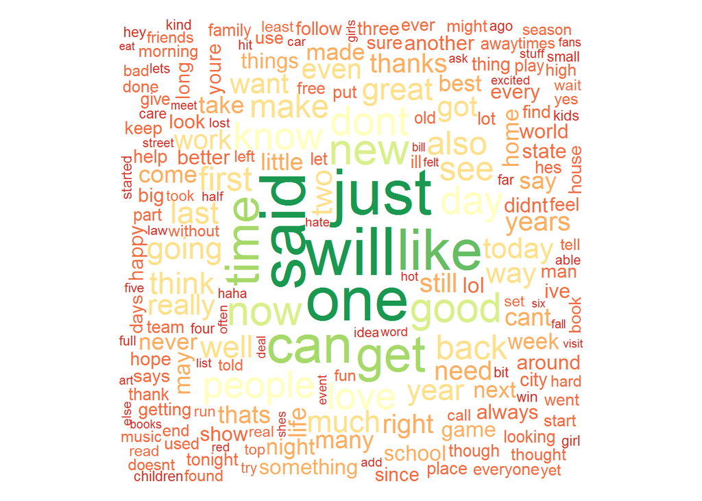

```r
library(wordcloud)
suppressWarnings(wordcloud(sampleClean, max.words = 500, random.order = FALSE, colors=brewer.pal(9, "RdYlGn")))
```

## N-Grams

Next, I will be calculating the n-grams, “a contiguous sequence of n items from a given sequence of text or speech”, to see the words that occur together most frequently.

Initially, I’ve trived using the functions available within “tm” pacakage, but was running into memory constrains. On the contrary, the “quanteda” package was quite fast and I’ve chosen to use this package for the n-gram generations.

## Unigrams

```r
suppressMessages(library(quanteda))
```

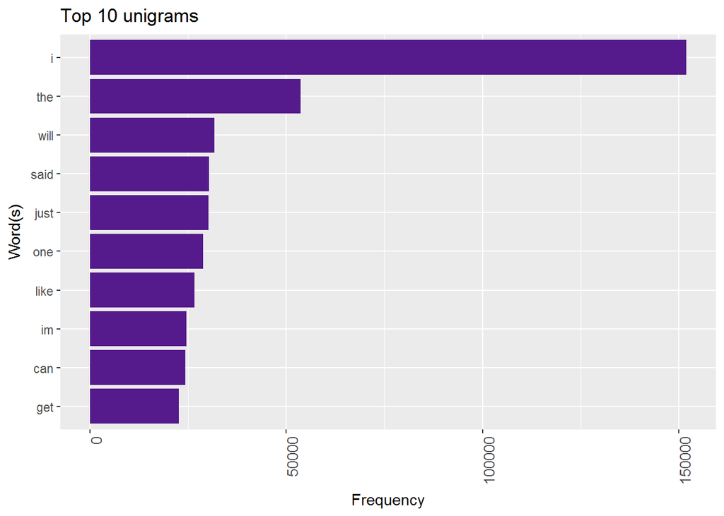

```r
# function to create n-grams


tokenizedDF <- function(obj, n) {
        nGramSparse <- dfm(obj, ngrams= n, concatenator = " ")
        nGramDF <- data.frame(Content = featnames(nGramSparse), Frequency = colSums(nGramSparse),
                 row.names = NULL, stringsAsFactors = FALSE)
                }

# function to plot the top 10 n-grams
library(ggplot2)
top10Plot <- function(df, title) {
          ggplot(df[1:10,], aes(reorder(Content, Frequency), Frequency)) +
          labs(x = "Word(s)", y = "Frequency") +
          theme(axis.text.x = element_text(angle = 90, size = 10, hjust = 1)) +
          coord_flip() +
          ggtitle(title) +
          geom_bar(stat = "identity", fill = I("purple4"))
          }


# uni-gram
uniGram <- tokenizedDF(sampleClean, 1)
# sorted
uniGram <- uniGram[order(uniGram$Frequency,decreasing = TRUE),]
#head(uniGram,10)

#plot top 10
top10Plot(uniGram, "Top 10 unigrams")
```

## Bigrams

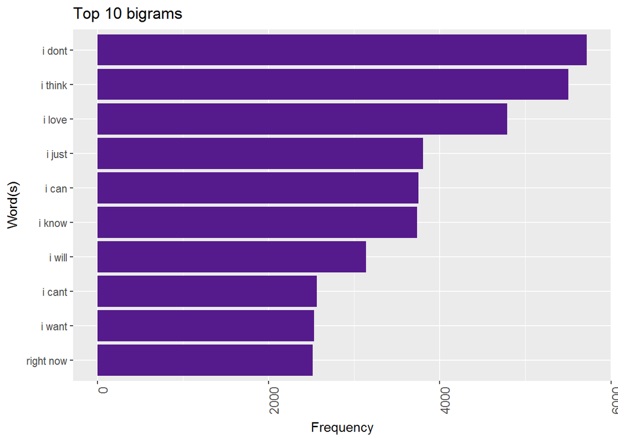

```r
biGram <- tokenizedDF(sampleClean, 2)
#sorted
biGram <- biGram[order(biGram$Frequency,decreasing = TRUE),]
#plot top 10
top10Plot(biGram, "Top 10 bigrams")
```

## Trigrams

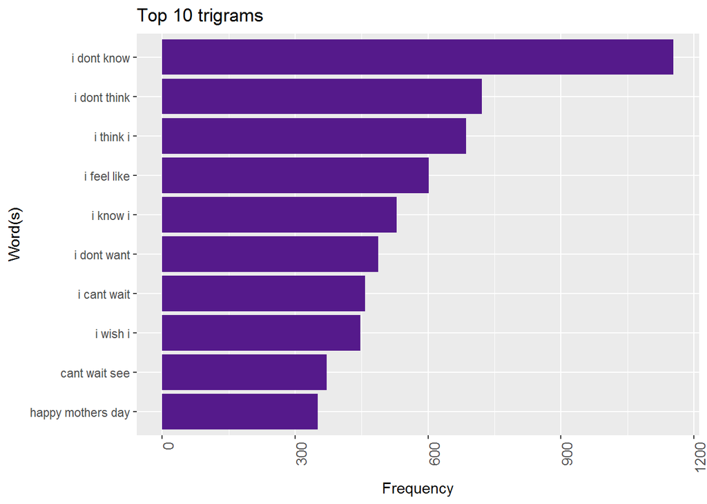

```r
triGram <- tokenizedDF(sampleClean, 3)
#sorted
triGram <- triGram[order(triGram$Frequency,decreasing = TRUE),]
#plot top 10
top10Plot(triGram, "Top 10 trigrams")
```

## Quadgrams

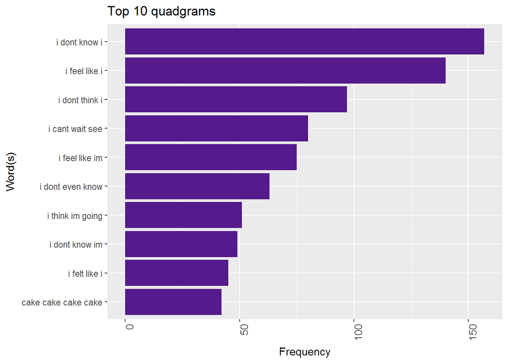

```r
quadGram <- tokenizedDF(sampleClean, 4)
#sorted
quadGram <- quadGram[order(quadGram$Frequency,decreasing = TRUE),]
#plot top 10
top10Plot(quadGram, "Top 10 quadgrams")
```

# 5. Way forward

In order to increase the efficincy of the shiny app, I think it will be a good idea to have the n-grams generated and saved prior rather than generating the n-grams in the run time which will results in bad user experience. Based on my research, “stupid Backoff” strategy seems like a good fit for developing the model i.e. to start with the quadgrams to see if there is a match with the first three words, then use the fourth word of the quadgram as the predicted word, if no match found then falling back to bigrams and so on.

# References

Expletives List https://www.freewebheaders.com/wordpress/wp-content/uploads/full-list-of-bad-words-banned-by-google-txt-file.zip

Introduction to the tm Package Text Mining in R https://cran.r-project.org/web/packages/tm/vignettes/tm.pdf

quanteda: Quantitative Analysis of Textual Data http://pnulty.github.io/

n-gram https://en.wikipedia.org/wiki/N-gram

smoothing+backoff-1 https://www.cs.cornell.edu/courses/CS4740/2012sp/lectures/smoothing+backoff-1-4pp.pdf